## Executive Summary

You work for Motor Trend, a magazine about the automobile industry. Looking at a data set of a collection of cars, they are interested in exploring the relationship between a set of variables and miles per gallon (MPG) (outcome). They are particularly interested in the following two questions:

- “Is an automatic or manual transmission better for MPG”
- “Quantify the MPG difference between automatic and manual transmissions”

## Is an automatic or manual transmission better for MPG?

For this topic I will use the confidence intervals and a t test to verify this.

For the confidence interval (see fig 1 in order to have a fast view of the differences in a boxplot):

```r
mtcars$transmition<-factor(mtcars$am,labels = c("automatic","manual"))
mtcars$cyl<-factor(mtcars$cyl)
mtcars$vs<-factor(mtcars$vs)
mtcars$gear<-factor(mtcars$gear)
mtcars$carb<-factor(mtcars$carb)
spliteddata<-split(mtcars,mtcars$transmition)
```

Interval for manual:

```
## [1] 20.66593 28.11869
```

Interval for automatic:

```
## [1] 15.29946 18.99528
```

Doing a t test:

```r
testMpg<-t.test(spliteddata$automatic$mpg,spliteddata$manual$mpg, alternative = "two.sided", paired=FALSE, var.equal = FALSE)
testMpg
```

```
##
##  Welch Two Sample t-test
##
## data:  spliteddata$automatic$mpg and spliteddata$manual$mpg
## t = -3.7671, df = 18.332, p-value = 0.001374
## alternative hypothesis: true difference in means is not equal to 0
## 95 percent confidence interval:
##  -11.280194  -3.209684
## sample estimates:
## mean of x mean of y
##  17.14737  24.39231
```

## Quantify the MPG difference between automatic and manual transmissions

We will get the best model to describe the effects on mpg:

See fig 3 and 4 for a comparison of the linear models for every regressor fig 3 depicts the regressors for manual transmission and 4 for automatic.

```r
fit<-lm(mpg~.,mtcars)
model<-step(fit)
```

```r
summary(model)
```

```
##
## Call:
## lm(formula = mpg ~ cyl + hp + wt + am, data = mtcars)
##
## Residuals:
##     Min      1Q  Median      3Q     Max
## -3.9387 -1.2560 -0.4013  1.1253  5.0513
##
## Coefficients:
##             Estimate Std. Error t value Pr(>|t|)
## (Intercept) 33.70832    2.60489  12.940 7.73e-13 ***
## cyl6        -3.03134    1.40728  -2.154  0.04068 *
## cyl8        -2.16368    2.28425  -0.947  0.35225
## hp          -0.03211    0.01369  -2.345  0.02693 *
## wt          -2.49683    0.88559  -2.819  0.00908 **
## am           1.80921    1.39630   1.296  0.20646
## ---
## Signif. codes:  0 '***' 0.001 '**' 0.01 '*' 0.05 '.' 0.1 ' ' 1
##
## Residual standard error: 2.41 on 26 degrees of freedom
## Multiple R-squared:  0.8659, Adjusted R-squared:  0.8401
## F-statistic: 33.57 on 5 and 26 DF,  p-value: 1.506e-10
```

## Appendix

Fig 1.

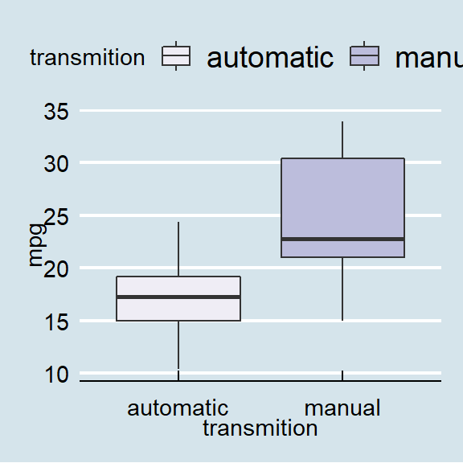

Fig 2.

[figure not shown]

Fig 3.

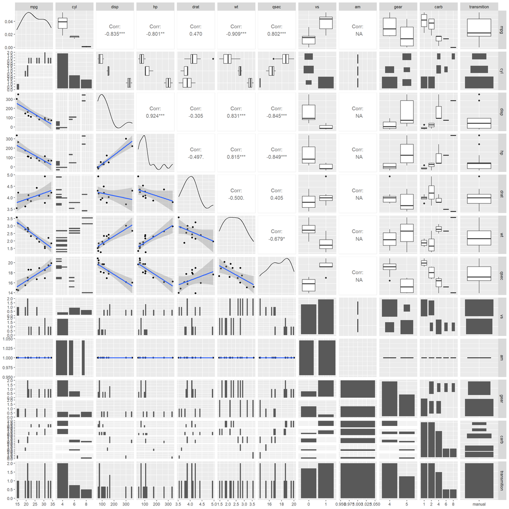

Fig 4.

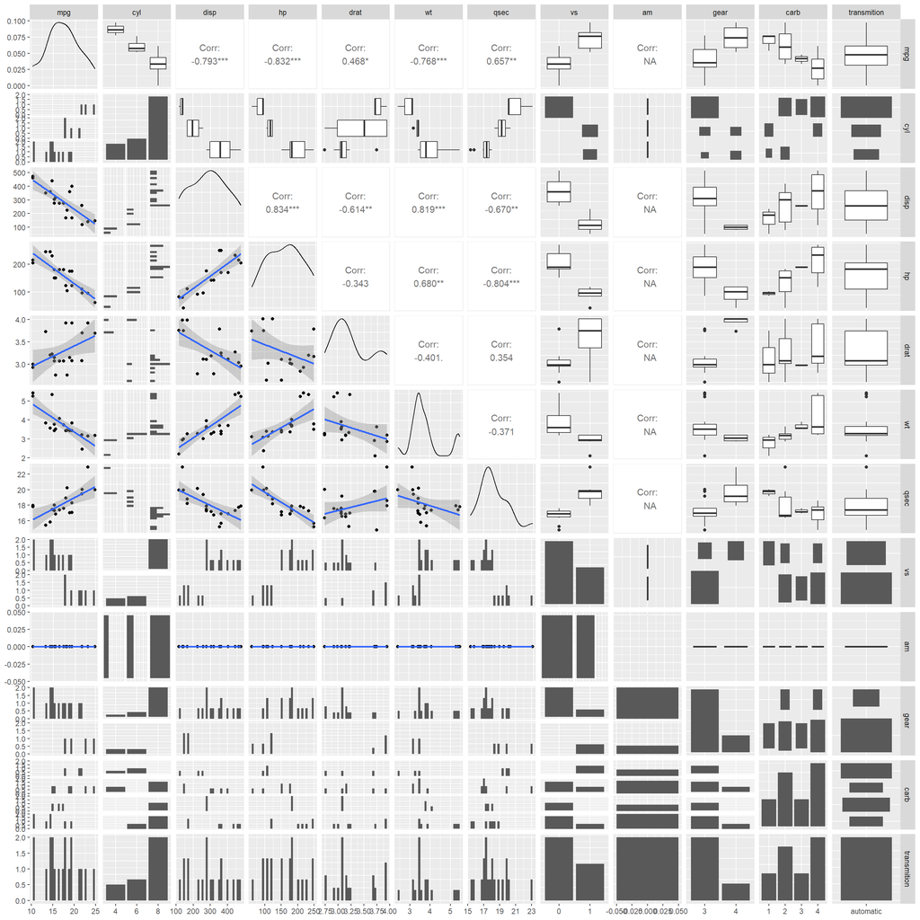